# Mobile App Rating Prediction

# All that is left to do is predict on our testing set

## Recall that long ago I set up the testing data using our data cleaning function under the dataframe testing

## To predict with the model all I will need to do is remove the duplicate variables as we did at the start with the training data then convert testing into a model matrix to get the dummy variables.

```r
test_data<-testing[c("Category", "Rating", "Reviews", "Size", "Installs", "Price", "Content.Rating","Current.Ver", "Android.Ver", "Days")]
## There are factors in our training set which are not in our testing set so I will have to add them in as 0 column vectors to the testing dummy matrix
test_data["Content.RatingEveryone"]<-0
test_data["Content.RatingUnrated"]<-0

dummy_Test<-model.matrix(Rating~.,test_data)
test_y<-test_data$Rating

testing_preds<-predict_review(dummy_Test)
rmse(test_y, testing_preds)
```

```
## [1] 0.6050939
```

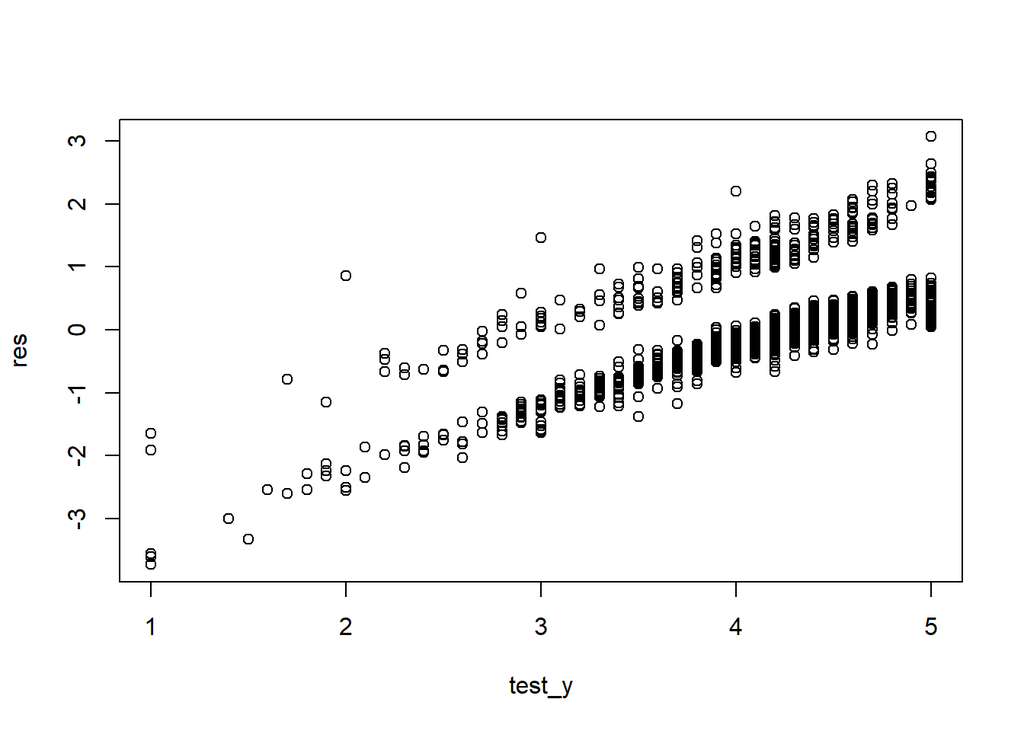

```r
res<-test_y-testing_preds
plot(test_y,res)
```

```r
true_test_pop<-c()
for(i in seq(length(test_y))){
  if(test_y[i] < 3.5){
    true_test_pop<-append(true_test_pop,"Bad")
  }
  else{
    true_test_pop<-append(true_test_pop,"Popular")
  }
}

test_pred_pop<-c()
for(i in seq(length(testing_preds))){
  if(testing_preds[i]<3.5){
    test_pred_pop<-append(test_pred_pop,"Bad")
  }
  else{
    test_pred_pop<-append(test_pred_pop,"Popular")
  }
}
table(true_test_pop,test_pred_pop)
```

```
##              test_pred_pop
## true_test_pop  Bad Popular
##       Bad       52     167
##       Popular  220    2370
```

# What happened? We used too many features in our models! I dont know why the Interviewer wanted me to use the top 20 features from the training data in the model, I will instead try to limit to the top 10

## Also I have realized 2 things

## 1. I forgot to include the Days variable in my list of variables so I will add that in

## 2. My intermediate regressor model only works if I have a large number of samples on which we predicted a bad app originally, so I will tune the classifier percentages to excessively favor predicting the bad class

## Retuning the Initial CLassifier on the top 10 features

```r
set.seed(5)
#pop_classifier<-randomForest(dummy_Train,true_pop, ntree=100, max_nodes = 1000, importance = T, classwt = c(0.999999, 0.000001))
pop_classifier<-randomForest(dummy_Train,true_pop, ntree=100, max_nodes = 1000, importance = T, classwt = c(1.5, 0.000001))
importance(pop_classifier)
```

```
##                                    Bad      Popular MeanDecreaseAccuracy MeanDecreaseGini
## (Intercept)                  0.0000000   0.00000000           0.00000000     0.000000e+00
## CategoryAUTO_AND_VEHICLES   -0.9798467   6.79141914           6.43280154     1.642600e-04
## CategoryBEAUTY              -0.7189728   7.11892088           6.49213685     3.547398e-03
## CategoryBOOKS_AND_REFERENCE -0.8281887   1.97131419           1.72774392     3.351038e-05
## CategoryBUSINESS             0.6684874   2.44678238           2.49846078     2.029872e-05
## CategoryCOMICS              -0.0717480  -0.04387797          -0.07850891     1.152569e-04
## CategoryCOMMUNICATION        1.3273571   3.70014254           3.87148548     4.634338e-05
## CategoryDATING               2.3017339  -1.87220779          -1.44535600     5.786533e-06
## CategoryEDUCATION           10.5227220   5.67545767           8.02990394     2.362791e-03
## CategoryENTERTAINMENT        0.9973502   1.38209186           1.55682889     5.721833e-04
## CategoryEVENTS               3.9328856   7.75740349           8.41362247     3.316554e-03
## CategoryFAMILY               1.3359918  -0.79636411          -0.63312604     3.220550e-05
## CategoryFINANCE             -0.2617740   3.81867108           3.95683992     3.588864e-05
## CategoryFOOD_AND_DRINK      -0.6363958   0.77699531           0.62983503     2.743604e-05
## CategoryGAME                 0.8383527  -1.43435512          -1.36686751     3.724678e-05
## CategoryHEALTH_AND_FITNESS  -0.6628084   4.20858809           4.08875956     3.962460e-05
## CategoryHOUSE_AND_HOME      -1.0382776   1.16852758           1.01361945     2.031208e-04
## CategoryLIBRARIES_AND_DEMO   0.2061294   7.41698387           7.43397954     4.849609e-04
## CategoryLIFESTYLE           -0.7909506   1.90491154           1.82645612     3.085667e-05
## CategoryMAPS_AND_NAVIGATION  1.5397507   2.66688252           2.93399408     1.860466e-05
## CategoryMEDICAL             -0.7694326  -0.23779751          -0.40530305     1.770662e-05
## CategoryNEWS_AND_MAGAZINES  -0.8557992   1.77682673           1.61146985     2.618881e-05
## CategoryPARENTING            7.2478069   9.71798284          10.59053437     7.024144e-03
## CategoryPERSONALIZATION      3.4833859   5.45593208           5.99896417     6.149850e-05
## CategoryPHOTOGRAPHY          1.1198774   2.52345744           2.67826561     3.722261e-05
## CategoryPRODUCTIVITY        -0.5629940   2.38782189           2.15648699     3.244017e-05
## CategorySHOPPING             2.0650527   3.38639046           3.73278118     1.166200e-04
## CategorySOCIAL               1.6816832   0.87548718           1.23115241     8.966814e-05
## CategorySPORTS              -0.5055924   1.54679913           1.54491637     4.036957e-05
## CategoryTOOLS                4.1607833  -1.55930431          -0.32455754     1.335543e-05
## CategoryTRAVEL_AND_LOCAL     1.4087444   3.27007022           3.58423637     1.598760e-05
## CategoryVIDEO_PLAYERS        1.8803847   1.92988215           2.26262551     1.405136e-05
## CategoryWEATHER              1.5077667   2.95326724           3.09429290     1.910192e-03
## Reviews                     28.5253247 -17.67382620         -13.80659604     3.305525e-02
## Size                         8.0486038  -5.13273877          -4.46742807     7.703498e-03
## Installs                    17.9158943 -14.74278796         -13.37057667     9.704020e-03
## Price                       -0.4869772   6.80717472           6.35446882     6.918709e-03
## Content.RatingEveryone       3.2890336  -1.44500633          -0.99648592     4.076011e-05
## Content.RatingEveryone 10+   1.1379563  -2.10427642          -1.80360111     6.813680e-05
## Content.RatingMature 17+     2.6932630   0.21456965           0.75093532     2.273841e-05
## Content.RatingTeen           2.6605987  -1.87484200          -1.64573308     5.940098e-05
## Content.RatingUnrated        0.0000000   0.00000000           0.00000000     0.000000e+00
## Current.Ver                  2.6135885  -4.31393272          -4.32921267     8.003896e-04
## Android.Ver                  3.7148083  -4.63164008          -4.51860206     5.422959e-04
## Days                        -0.1781688   0.63597280           0.59469568     2.700218e-03
```

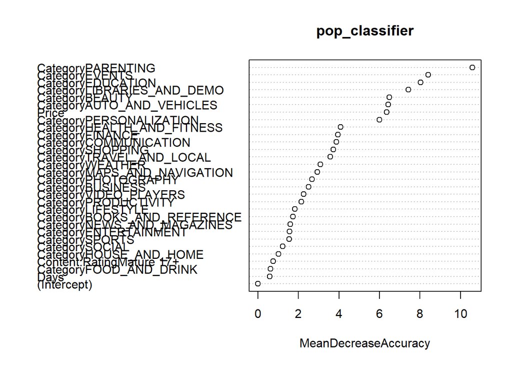

```r
varImpPlot(pop_classifier, type = 1)
```

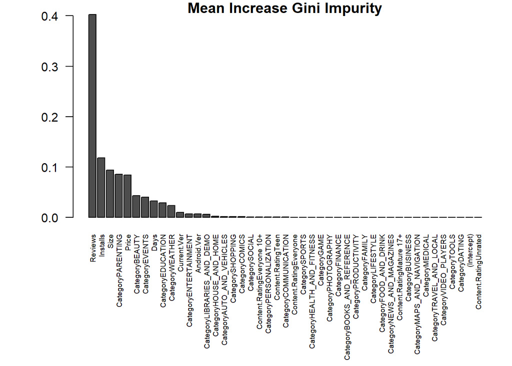

```r
var.imp1 <- data.frame(importance(pop_classifier, type=2))
var.imp1$Variables <- row.names(var.imp1)
varimp1 <- var.imp1[order(var.imp1[1],decreasing = T),]
par(mar=c(10,5,1,1))
giniplot <- barplot(t(varimp1[-2]/sum(varimp1[-2])),las=2,
                     cex.names=0.6,
                    main="Mean Increase Gini Impurity")
```

```r
clas_preds<-predict(pop_classifier, dummy_Train)

table(true_pop,clas_preds)
```

```
##          clas_preds
## true_pop   Bad Popular
##   Bad      515       0
##   Popular 3158    2885
```

```r
set.seed(5)
df<-data.frame(dummy_Train)
clas_top10<-df[c("Reviews","Installs","Size","CategoryPARENTING","Price","CategoryBEAUTY","CategoryEVENTS","Days","CategoryEDUCATION","CategoryWEATHER")]

pop_classifier<-randomForest(clas_top10,true_pop, ntree=100, max_nodes = 1000, importance = T, classwt = c(1.5, 0.000001))

importance(pop_classifier)
```

```
##                          Bad    Popular MeanDecreaseAccuracy MeanDecreaseGini
## Reviews           19.4918506 -11.882738            -9.468499      0.030483234
## Installs          15.5832921 -13.427255           -12.667202      0.009122395
## Size               5.4055332  -3.830152            -3.067335      0.005057021
## CategoryPARENTING  7.0247075   9.447812            10.570119      0.006041892
## Price              4.8386985   1.644281             2.403969      0.008078831
## CategoryBEAUTY     0.4360291   5.766346             5.310932      0.003944763
## CategoryEVENTS     2.7581496   7.646574             7.421581      0.003444826
## Days               0.5989246  -3.224196            -3.181679      0.001460571
## CategoryEDUCATION 12.3223059   4.738988             8.650695      0.002254954
## CategoryWEATHER    4.0961571   1.863953             2.791745      0.001935846
```

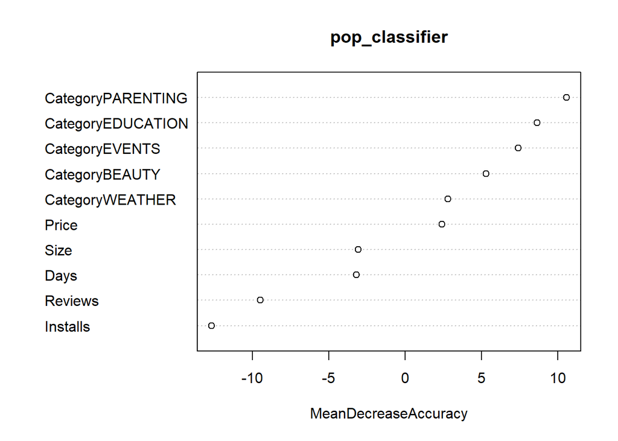

```r
varImpPlot(pop_classifier, type = 1)
```

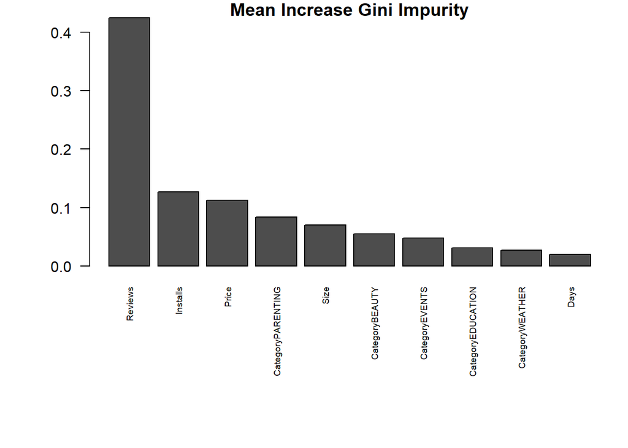

```r
var.imp1 <- data.frame(importance(pop_classifier, type=2))
var.imp1$Variables <- row.names(var.imp1)
varimp1 <- var.imp1[order(var.imp1[1],decreasing = T),]
par(mar=c(10,5,1,1))
giniplot <- barplot(t(varimp1[-2]/sum(varimp1[-2])),las=2,
                     cex.names=0.6,
                    main="Mean Increase Gini Impurity")
```

```r
clas_preds<-predict(pop_classifier, clas_top10)

table(true_pop,clas_preds)
```

```
##          clas_preds
## true_pop   Bad Popular
##   Bad      515       0
##   Popular 4565    1478
```

```r
lows<-which(true_pop == "Bad")
highs<-which(true_pop == "Popular")
low_dummy<-dummy_Train[lows,]
high_dummy<-dummy_Train[highs,]
low_rats<-train_y[lows]
high_rats<-train_y[highs]
```

```r
set.seed(742)

rf_Model_low<-randomForest(low_dummy,low_rats, ntree=100, max_nodes = 1000, importance = T)

importance(rf_Model_low)
```

```
##                                 %IncMSE IncNodePurity
## (Intercept)                  0.00000000   0.000000000
## CategoryAUTO_AND_VEHICLES   -0.89549214   0.512123748
## CategoryBEAUTY               0.00000000   0.015923649
## CategoryBOOKS_AND_REFERENCE  1.82651677   0.364601217
## CategoryBUSINESS            -1.54379454   1.031454720
## CategoryCOMICS              -0.21180950   0.114135132
## CategoryCOMMUNICATION       -2.07706164   1.883431942
## CategoryDATING               0.20389783   1.436091422
## CategoryEDUCATION            0.00000000   0.000000000
## CategoryENTERTAINMENT       -1.37763825   0.008760592
## CategoryEVENTS               0.00000000   0.002760462
## CategoryFAMILY              -0.21969977   2.332988382
## CategoryFINANCE             -0.30369946   2.090286917
## CategoryFOOD_AND_DRINK       1.64461171   1.455399888
## CategoryGAME                 0.42586582   0.734469884
## CategoryHEALTH_AND_FITNESS   3.32292039   1.672725438
## CategoryHOUSE_AND_HOME       1.16229452   0.098984388
## CategoryLIBRARIES_AND_DEMO   1.22654968   0.039856416
## CategoryLIFESTYLE            2.81855045   1.393008177
## CategoryMAPS_AND_NAVIGATION  1.16887552   0.322406999
## CategoryMEDICAL              1.85072375   2.551178895
## CategoryNEWS_AND_MAGAZINES   0.98132516   1.029690794
## CategoryPARENTING            0.00000000   0.000000000
## CategoryPERSONALIZATION     -0.87918812   0.052980271
## CategoryPHOTOGRAPHY          1.33335910   1.072643163
## CategoryPRODUCTIVITY         0.70420992   0.528771069
## CategorySHOPPING             0.68750230   0.673324235
## CategorySOCIAL              -2.68837716   0.439353750
## CategorySPORTS              -2.27878490   0.420353981
## CategoryTOOLS               -0.48347655   2.151206500
## CategoryTRAVEL_AND_LOCAL    -2.11956074   0.448724166
## CategoryVIDEO_PLAYERS       -1.99226160   0.336608795
## CategoryWEATHER              0.00000000   0.037878143
## Reviews                     11.34904282  32.285326775
## Size                         1.09554208  15.376074232
## Installs                     6.78071866  17.950733625
## Price                        3.18191435   1.930399727
## Content.RatingEveryone       1.43498831   1.160935875
## Content.RatingEveryone 10+   1.48762872   0.304043258
## Content.RatingMature 17+    -1.85987281   0.616616136
## Content.RatingTeen           1.68355444   0.950071425
## Content.RatingUnrated        0.00000000   0.000000000
## Current.Ver                  1.67885315  13.112560613
## Android.Ver                  2.23778182   7.829537449
## Days                         0.07839085  19.152264790
```

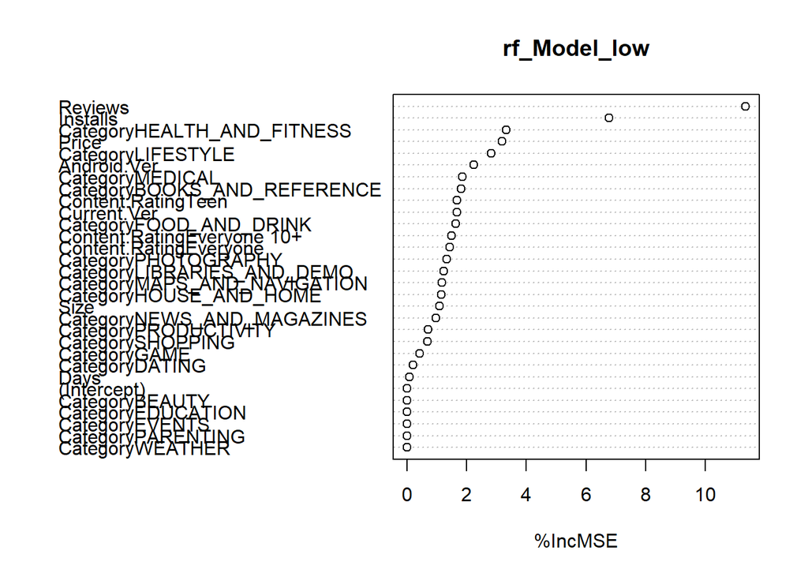

```r
varImpPlot(rf_Model_low, type = 1)
```

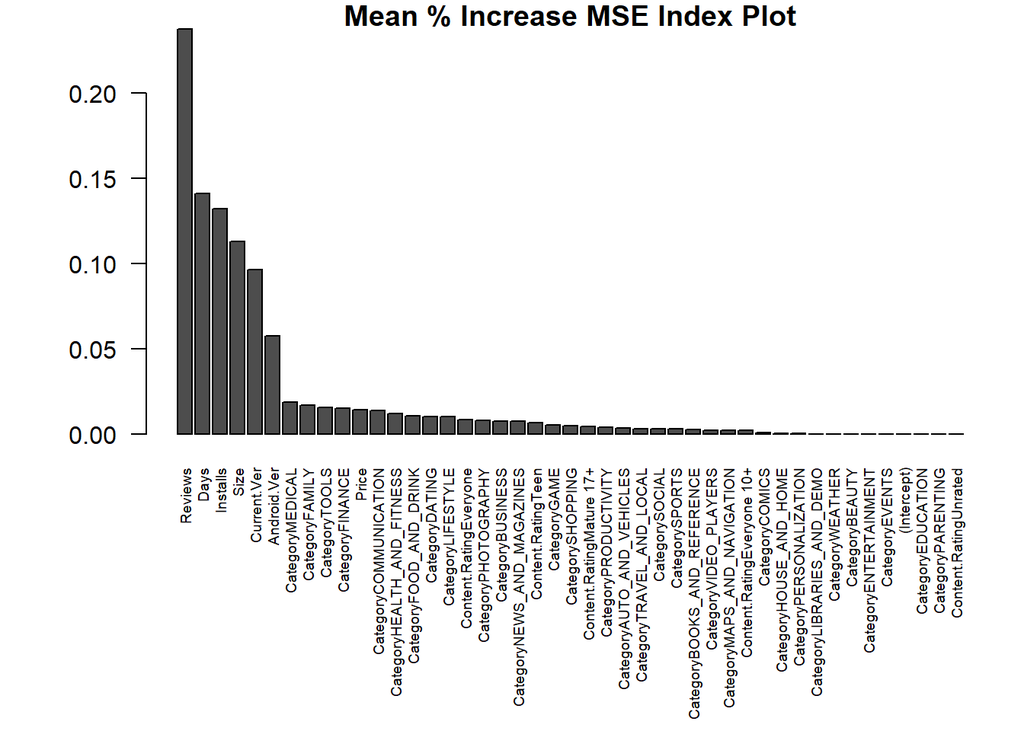

```r
var.imp1 <- data.frame(importance(rf_Model_low, type=2))
var.imp1$Variables <- row.names(var.imp1)
varimp1 <- var.imp1[order(var.imp1[1],decreasing = T),]
par(mar=c(10,5,1,1))
giniplot <- barplot(t(varimp1[-2]/sum(varimp1[-2])),las=2,
                     cex.names=0.6,
                    main="Mean % Increase MSE Index Plot")
```

```r
preds_low<- predict(rf_Model_low, low_dummy)

rmse(low_rats, preds_low)
```

```
## [1] 0.2335072
```

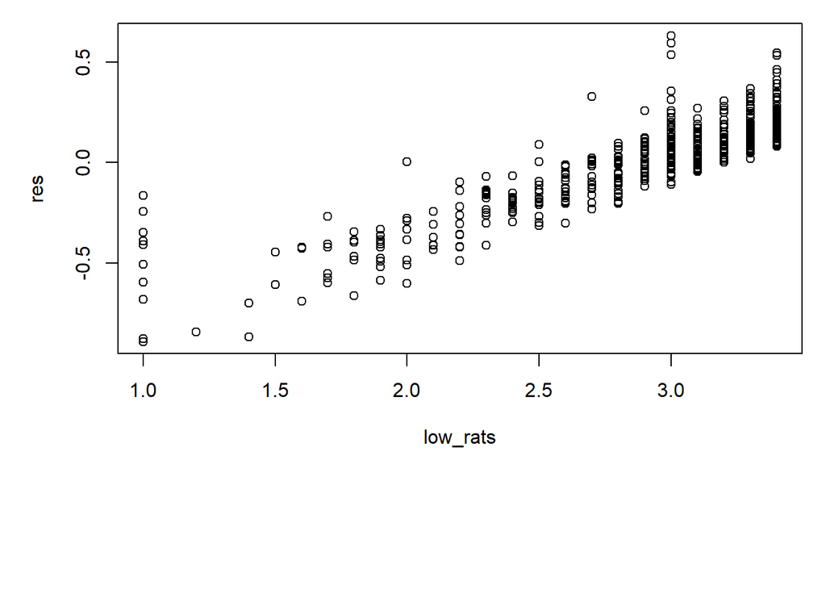

```r
res<-low_rats-preds_low
plot(low_rats,res)
```

## Retuning the Low Rating Regressor on the top 10 features

```r
df<-data.frame(low_dummy)
low_top10<-df[c("Reviews", "Days","Installs", "Size", "Current.Ver", "Android.Ver", "CategoryMEDICAL", "CategoryFAMILY","CategoryTOOLS", "CategoryFINANCE")]

set.seed(452)

rf_Model_low<-randomForest(low_top10,low_rats, ntree=100, max_nodes = 1000, importance = T)

importance(rf_Model_low)
```

```
##                      %IncMSE IncNodePurity
## Reviews         11.364154115     36.511125
## Days             1.057181413     22.610177
## Installs         6.117277452     18.314478
## Size             0.007755075     18.151965
## Current.Ver      0.493531211     17.123289
## Android.Ver     -0.664416011      9.913671
## CategoryMEDICAL  1.514321779      1.747550
## CategoryFAMILY   0.736206853      2.634881
## CategoryTOOLS   -1.004938249      2.445675
## CategoryFINANCE -1.785232755      2.020991
```

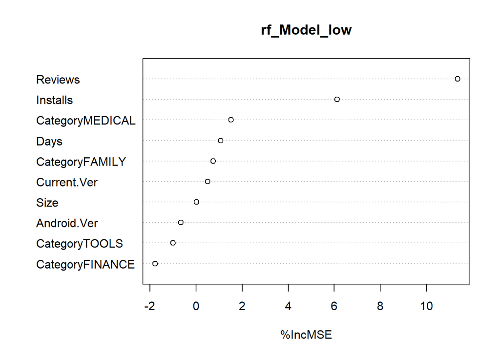

```r
varImpPlot(rf_Model_low, type = 1)
```

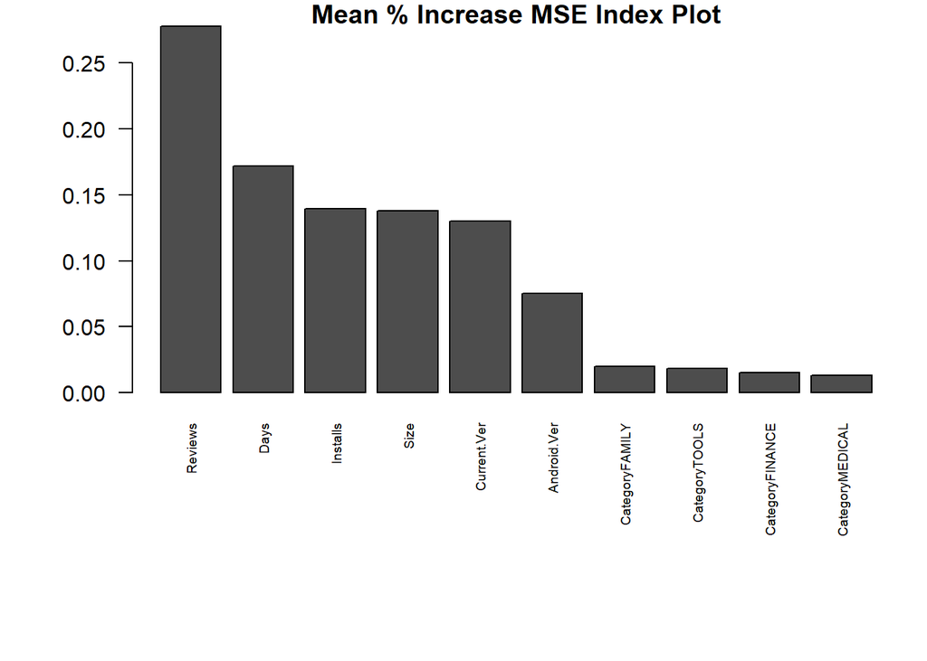

```r
var.imp1 <- data.frame(importance(rf_Model_low, type=2))
var.imp1$Variables <- row.names(var.imp1)
varimp1 <- var.imp1[order(var.imp1[1],decreasing = T),]
par(mar=c(10,5,1,1))
giniplot <- barplot(t(varimp1[-2]/sum(varimp1[-2])),las=2,
                     cex.names=0.6,
                    main="Mean % Increase MSE Index Plot")
```

```r
preds_low<- predict(rf_Model_low, low_dummy)

rmse(low_rats, preds_low)
```

```
## [1] 0.2480364
```

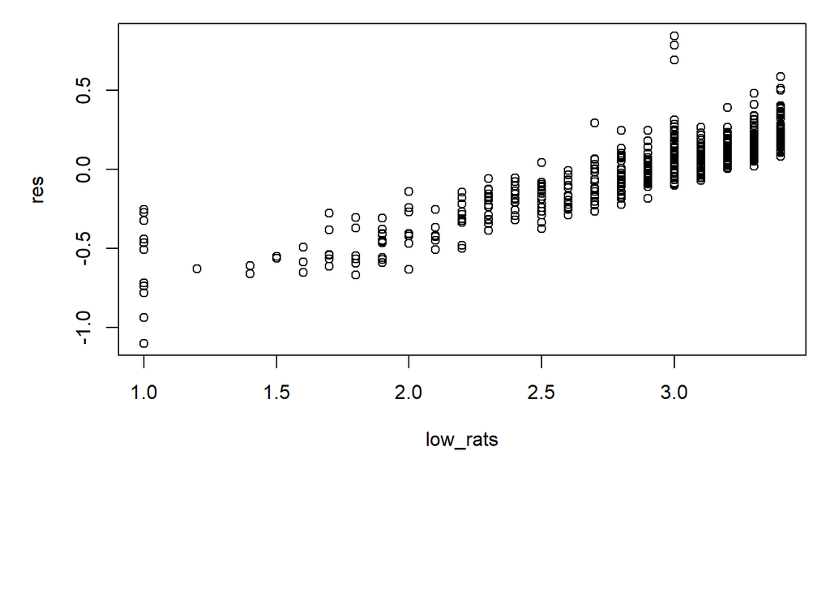

```r
res<-low_rats-preds_low
plot(low_rats,res)
```

```r
set.seed(120000)
rf_Model_high<-randomForest(high_dummy,high_rats, ntree=100, max_nodes = 1000, importance = T)

importance(rf_Model_high)
```

```
##                                %IncMSE IncNodePurity
## (Intercept)                  0.0000000  0.000000e+00
## CategoryAUTO_AND_VEHICLES    3.4957139  2.720684e+00
## CategoryBEAUTY               1.8690092  1.654695e+00
## CategoryBOOKS_AND_REFERENCE  3.5714099  4.116407e+00
## CategoryBUSINESS             2.1634656  4.209983e+00
## CategoryCOMICS              -3.9250388  1.786978e+00
## CategoryCOMMUNICATION        7.9396565  5.515712e+00
## CategoryDATING               6.5956745  2.880699e+00
## CategoryEDUCATION            5.7221034  2.252911e+00
## CategoryENTERTAINMENT        7.6689670  2.370889e+00
## CategoryEVENTS               0.4514993  6.431875e-01
## CategoryFAMILY               3.7432331  8.622360e+00
## CategoryFINANCE              1.7470849  4.711786e+00
## CategoryFOOD_AND_DRINK       4.1637130  2.791326e+00
## CategoryGAME                 6.4735883  5.273061e+00
## CategoryHEALTH_AND_FITNESS   8.9740319  4.604618e+00
## CategoryHOUSE_AND_HOME       0.5775623  1.456572e+00
## CategoryLIBRARIES_AND_DEMO   3.4122680  1.262570e+00
## CategoryLIFESTYLE            3.0248485  5.882475e+00
## CategoryMAPS_AND_NAVIGATION  2.7348350  3.194973e+00
## CategoryMEDICAL              4.1489613  5.422964e+00
## CategoryNEWS_AND_MAGAZINES   5.3747881  4.308062e+00
## CategoryPARENTING            4.2788987  1.661077e+00
## CategoryPERSONALIZATION      1.7975475  3.780838e+00
## CategoryPHOTOGRAPHY          2.9615834  2.828984e+00
## CategoryPRODUCTIVITY        -1.2704857  3.605146e+00
## CategorySHOPPING             1.8248194  2.179512e+00
## CategorySOCIAL               5.3177034  3.263402e+00
## CategorySPORTS               5.0198512  6.138015e+00
## CategoryTOOLS                3.0618374  5.987335e+00
## CategoryTRAVEL_AND_LOCAL     5.9667173  3.359562e+00
## CategoryVIDEO_PLAYERS        2.9876350  3.032813e+00
## CategoryWEATHER             -2.5583269  1.420117e+00
## Reviews                     34.9730532  1.277618e+02
## Size                        12.4031893  6.881145e+01
## Installs                    37.1325746  8.266306e+01
## Price                       12.9369478  1.423220e+01
## Content.RatingEveryone       7.8378751  6.362320e+00
## Content.RatingEveryone 10+   3.1569437  2.711385e+00
## Content.RatingMature 17+     7.1030851  4.445650e+00
## Content.RatingTeen           6.8490962  5.029727e+00
## Content.RatingUnrated        0.0000000  4.373757e-03
## Current.Ver                  3.3951489  5.138258e+01
## Android.Ver                  8.4700127  3.415731e+01
## Days                        12.8584705  7.933082e+01
```

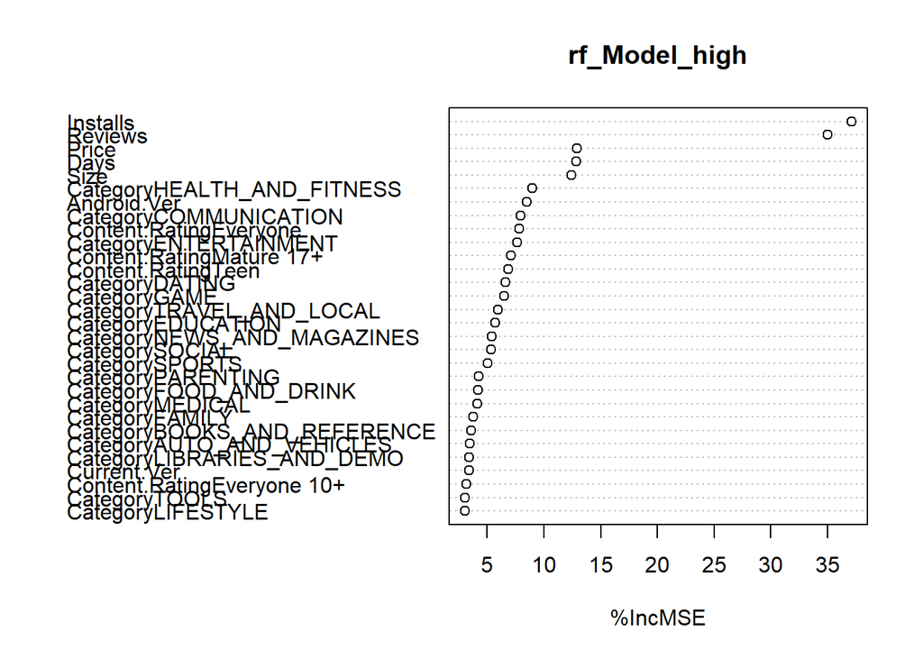

```r
varImpPlot(rf_Model_high, type = 1)
```

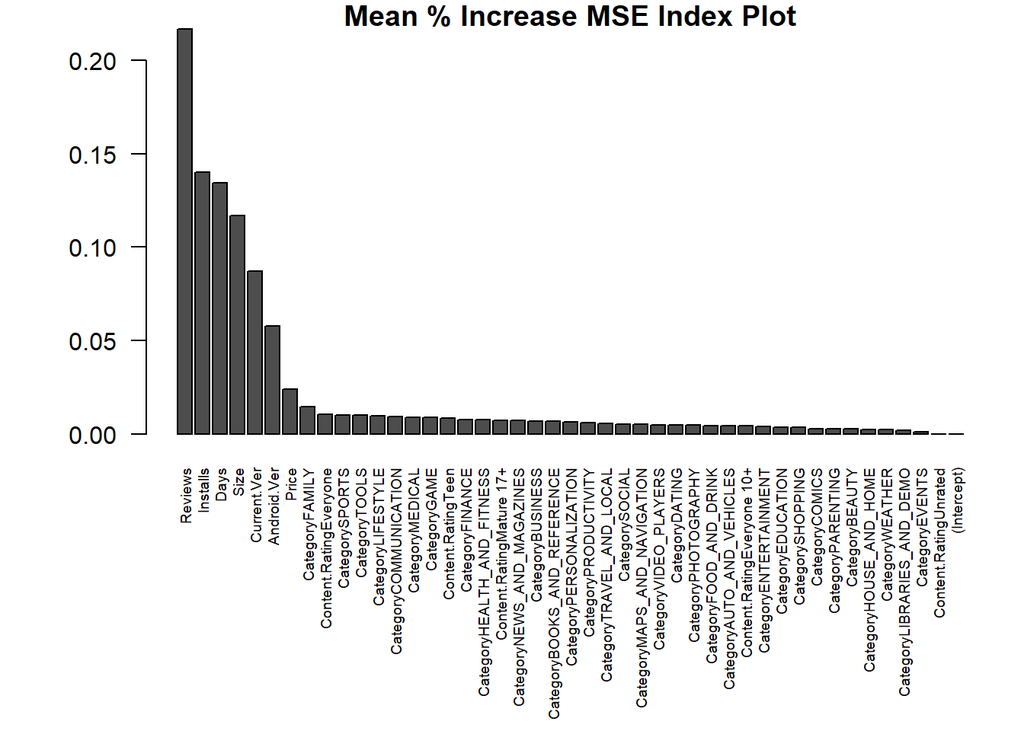

```r
var.imp1 <- data.frame(importance(rf_Model_high, type=2))
var.imp1$Variables <- row.names(var.imp1)
varimp1 <- var.imp1[order(var.imp1[1],decreasing = T),]
par(mar=c(10,5,1,1))
giniplot <- barplot(t(varimp1[-2]/sum(varimp1[-2])),las=2,
                     cex.names=0.6,
                    main="Mean % Increase MSE Index Plot")
```

```r
preds_high<- predict(rf_Model_high, high_dummy)

rmse(high_rats, preds_high)
```

```
## [1] 0.1354279
```

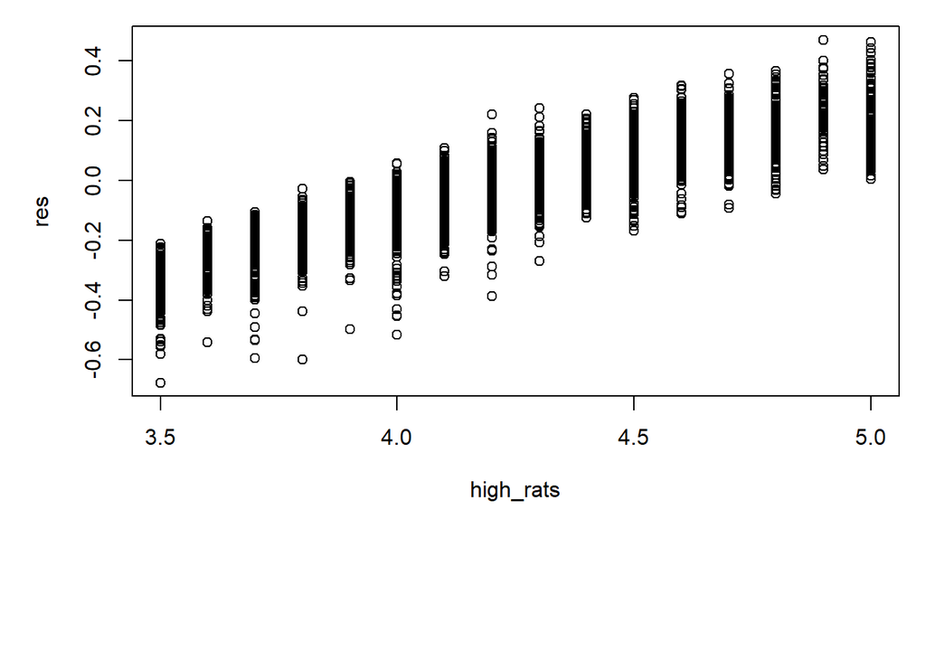

```r
res<-high_rats-preds_high
plot(high_rats,res)
```

## Retuning the High Rating Regressor on the top 10 features

```r
set.seed(1894)
df<-data.frame(high_dummy)
high_top10<-df[c("Reviews", "Installs", "Days", "Size", "Current.Ver", "Android.Ver", "Price", "CategoryFAMILY", "CategorySPORTS", "CategoryLIFESTYLE")]

rf_Model_high<-randomForest(high_top10,high_rats, ntree=100, max_nodes = 1000, importance = T)

importance(rf_Model_high)
```

```
##                     %IncMSE IncNodePurity
## Reviews           38.509520    145.546016
## Installs          37.555799     84.355156
## Days              11.468221     93.948620
## Size              11.825263     82.765145
## Current.Ver        6.261665     63.771663
## Android.Ver        9.454743     42.115981
## Price             17.650186     15.623143
## CategoryFAMILY     5.523329     10.637150
## CategorySPORTS     6.288290      6.147249
## CategoryLIFESTYLE  1.298373      6.337231
```

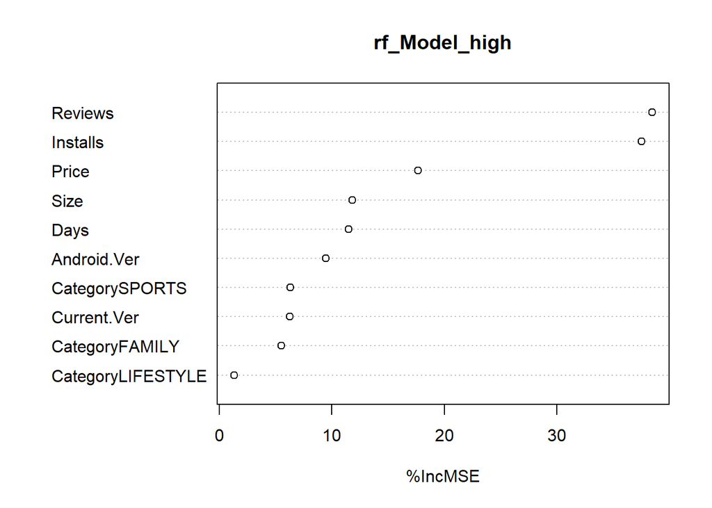

```r
varImpPlot(rf_Model_high, type = 1)
```

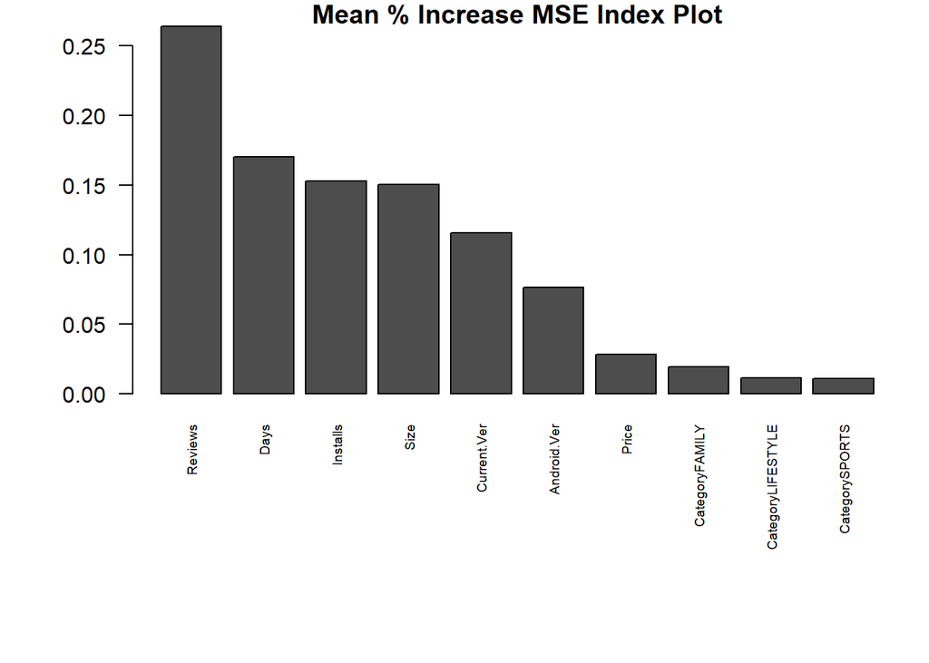

```r
var.imp1 <- data.frame(importance(rf_Model_high, type=2))
var.imp1$Variables <- row.names(var.imp1)
varimp1 <- var.imp1[order(var.imp1[1],decreasing = T),]
par(mar=c(10,5,1,1))
giniplot <- barplot(t(varimp1[-2]/sum(varimp1[-2])),las=2,
                     cex.names=0.6,
                    main="Mean % Increase MSE Index Plot")
```

```r
preds_high<- predict(rf_Model_high, high_dummy)

rmse(high_rats, preds_high)
```

```
## [1] 0.154047
```

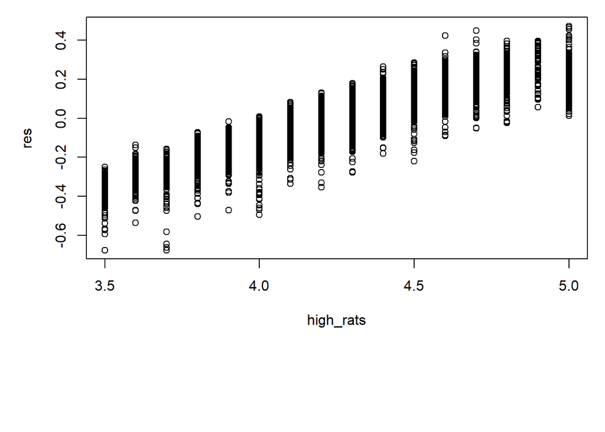

```r
res<-high_rats-preds_high
plot(high_rats,res)
```

```r
bads<-which(clas_preds == "Bad")
int_dummy<-dummy_Train[bads,]
int_rats<-train_y[bads]

set.seed(99999)

rf_Model_int<-randomForest(int_dummy,int_rats, ntree=100, max_nodes = 1000, importance = T)

importance(rf_Model_int)
```

```
##                                %IncMSE IncNodePurity
## (Intercept)                  0.0000000  0.000000e+00
## CategoryAUTO_AND_VEHICLES    0.6524718  4.861050e+00
## CategoryBEAUTY              -0.8029455  1.004461e+00
## CategoryBOOKS_AND_REFERENCE  2.0218892  6.522208e+00
## CategoryBUSINESS            -0.3374383  1.393333e+01
## CategoryCOMICS               0.7689753  5.807507e+00
## CategoryCOMMUNICATION       -0.1605565  1.078526e+01
## CategoryDATING               5.0579089  1.388885e+01
## CategoryEDUCATION            0.0000000  0.000000e+00
## CategoryENTERTAINMENT        5.1058876  3.031793e+00
## CategoryEVENTS              -2.7074425  7.147549e-01
## CategoryFAMILY               2.4319707  1.976794e+01
## CategoryFINANCE              1.3584004  1.516467e+01
## CategoryFOOD_AND_DRINK       2.4775786  8.419517e+00
## CategoryGAME                 3.8104105  9.527935e+00
## CategoryHEALTH_AND_FITNESS   7.5131579  1.695194e+01
## CategoryHOUSE_AND_HOME      -2.1365496  2.223847e+00
## CategoryLIBRARIES_AND_DEMO   0.5922023  2.865108e+00
## CategoryLIFESTYLE            2.2202795  1.487449e+01
## CategoryMAPS_AND_NAVIGATION -1.2888881  6.025506e+00
## CategoryMEDICAL             -1.4955636  1.631828e+01
## CategoryNEWS_AND_MAGAZINES  -0.8282852  1.114717e+01
## CategoryPARENTING            0.0000000  0.000000e+00
## CategoryPERSONALIZATION      5.5403004  7.782467e+00
## CategoryPHOTOGRAPHY          3.8995125  1.291991e+01
## CategoryPRODUCTIVITY        -1.2202362  1.242456e+01
## CategorySHOPPING             3.7394534  7.140592e+00
## CategorySOCIAL               1.0853472  6.242106e+00
## CategorySPORTS              -1.4875413  1.239720e+01
## CategoryTOOLS                3.9677572  1.975530e+01
## CategoryTRAVEL_AND_LOCAL     6.6502675  1.047189e+01
## CategoryVIDEO_PLAYERS        5.5022524  8.085231e+00
## CategoryWEATHER             -0.7169604  4.839440e-01
## Reviews                     20.5231390  2.653942e+02
## Size                         9.1331706  1.873399e+02
## Installs                    15.8412718  1.323073e+02
## Price                        5.9329630  3.029996e+01
## Content.RatingEveryone       4.1405404  1.179424e+01
## Content.RatingEveryone 10+   1.8871754  6.743040e+00
## Content.RatingMature 17+     3.5832000  9.043545e+00
## Content.RatingTeen           2.7209967  8.714500e+00
## Content.RatingUnrated        0.0000000  4.360129e-03
## Current.Ver                  1.6526929  1.446986e+02
## Android.Ver                  4.6209674  9.240895e+01
## Days                         5.9473230  2.068203e+02
```

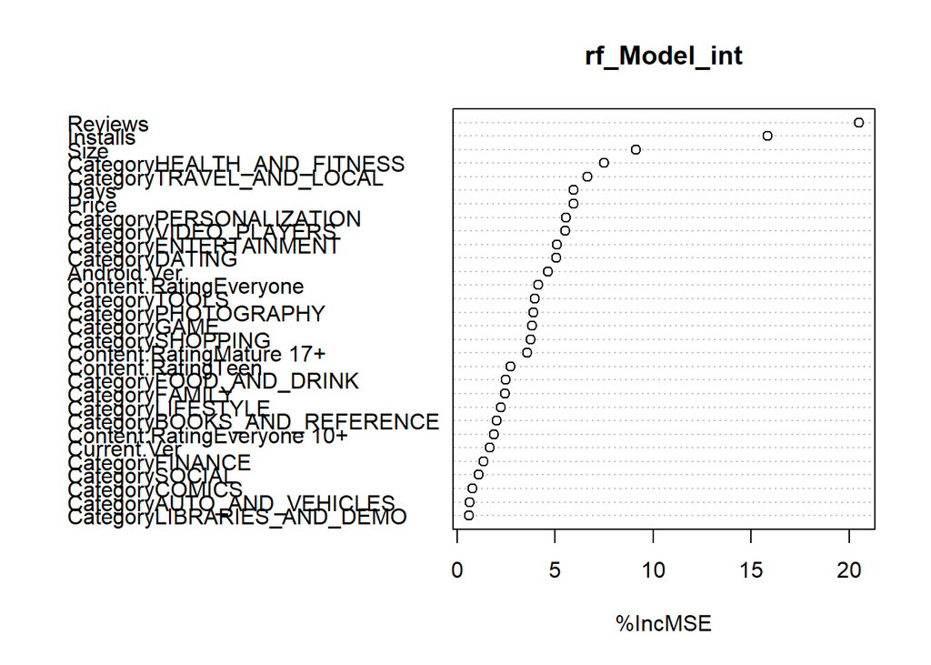

```r
varImpPlot(rf_Model_int, type = 1)
```

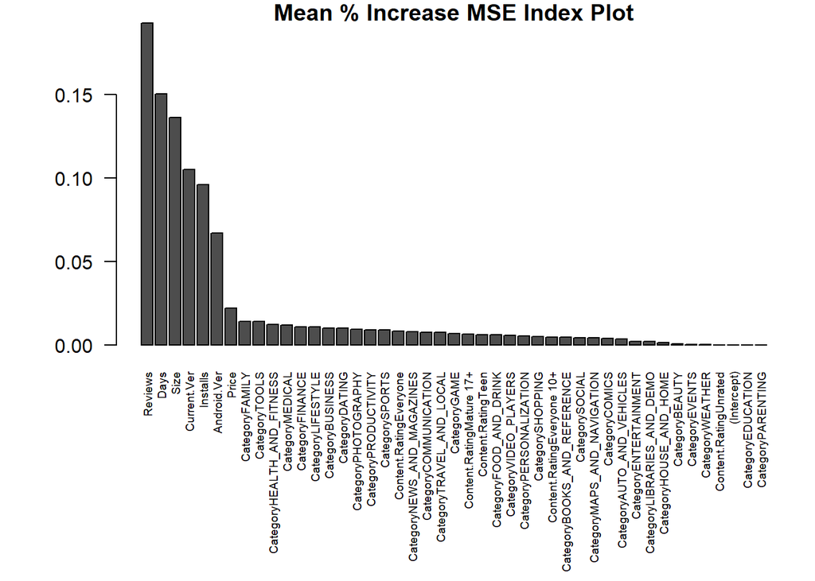

```r
var.imp1 <- data.frame(importance(rf_Model_int, type=2))
var.imp1$Variables <- row.names(var.imp1)
varimp1 <- var.imp1[order(var.imp1[1],decreasing = T),]
par(mar=c(10,5,1,1))
giniplot <- barplot(t(varimp1[-2]/sum(varimp1[-2])),las=2,
                     cex.names=0.6,
                    main="Mean % Increase MSE Index Plot")
```

```r
preds_int<- predict(rf_Model_int, int_dummy)

rmse(int_rats, preds_int)
```

```
## [1] 0.2602185
```

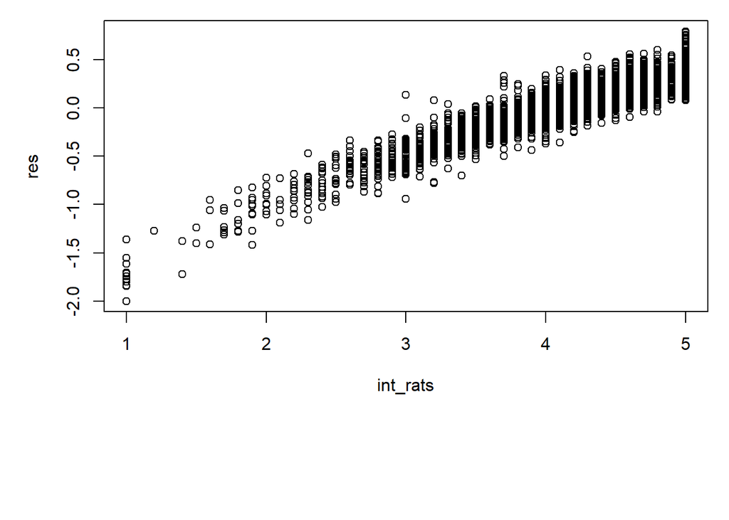

```r
res<-int_rats-preds_int
plot(int_rats,res)
```

```r
set.seed(72)
df<-data.frame(int_dummy)
int_top10<-df[c("Reviews","Size","Days","Current.Ver","Installs","Android.Ver","Price","CategoryTOOLS","CategoryFAMILY","CategoryHEALTH_AND_FITNESS")]

rf_Model_int<-randomForest(int_top10,int_rats, ntree=100, max_nodes = 1000, importance = T)

importance(rf_Model_int)
```

```
##                              %IncMSE IncNodePurity
## Reviews                    17.143993     306.96456
## Size                        8.625252     225.51084
## Days                        4.269593     250.11038
## Current.Ver                 3.666468     178.83949
## Installs                   15.000579     143.85414
## Android.Ver                 5.004127     113.39357
## Price                       6.164086      35.25335
## CategoryTOOLS               8.123134      19.30677
## CategoryFAMILY              0.436613      23.66943
## CategoryHEALTH_AND_FITNESS  7.179148      18.16694
```

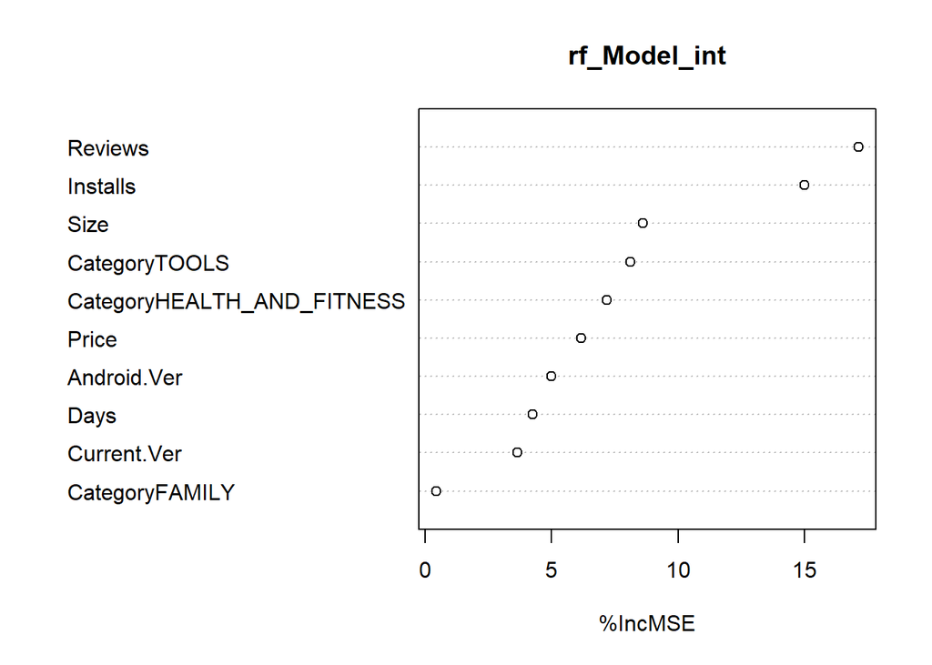

```r
varImpPlot(rf_Model_int, type = 1)
```

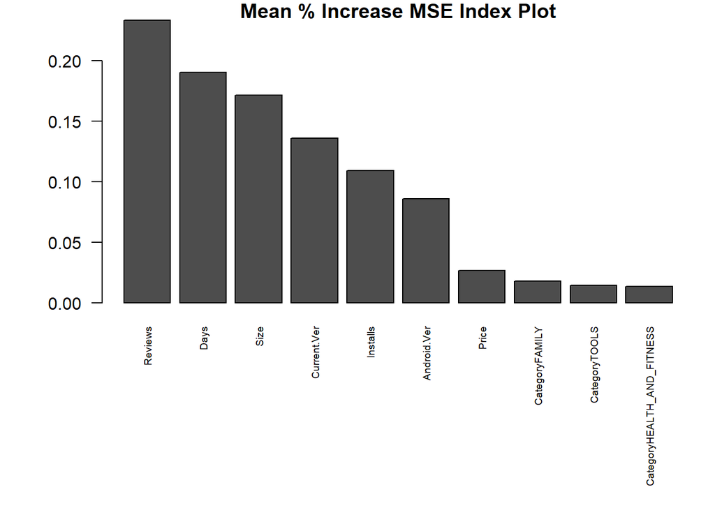

```r
var.imp1 <- data.frame(importance(rf_Model_int, type=2))
var.imp1$Variables <- row.names(var.imp1)
varimp1 <- var.imp1[order(var.imp1[1],decreasing = T),]
par(mar=c(10,5,1,1))
giniplot <- barplot(t(varimp1[-2]/sum(varimp1[-2])),las=2,
                     cex.names=0.6,
                    main="Mean % Increase MSE Index Plot")
```

```r
preds_int<- predict(rf_Model_int, int_dummy)

rmse(int_rats, preds_int)
```

```
## [1] 0.2801307
```

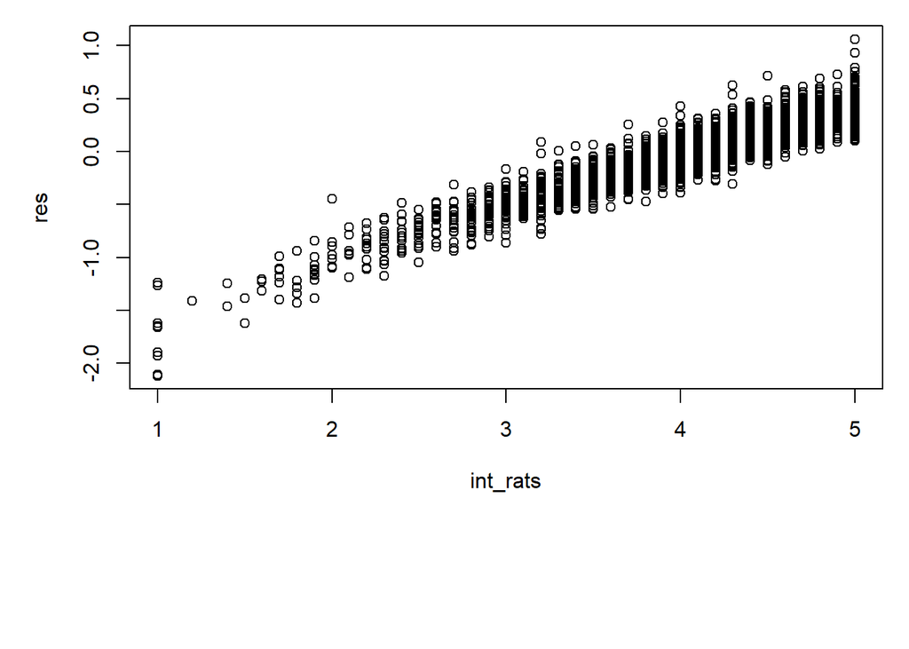

```r
res<-int_rats-preds_int
plot(int_rats,res)
```

## Rebuilding prediction function

```r
predict_review<-function(dummy_matrix, int_cut = 4){
  final_preds<-c()
  low_df<-data.frame(dummy_matrix)
  low_top10<-low_df[c("Reviews", "Days","Installs", "Size", "Current.Ver", "Android.Ver", "CategoryMEDICAL", "CategoryFAMILY","CategoryTOOLS", "CategoryFINANCE")]

  high_df<-data.frame(dummy_matrix)
  high_top10<-high_df[c("Reviews", "Installs", "Days", "Size", "Current.Ver", "Android.Ver", "Price", "CategoryFAMILY", "CategorySPORTS", "CategoryLIFESTYLE")]

  df<-data.frame(dummy_matrix)
  int_top10<-df[c("Reviews","Size","Days","Current.Ver","Installs","Android.Ver","Price","CategoryTOOLS","CategoryFAMILY","CategoryHEALTH_AND_FITNESS")]

  #First we do the inital classification using pop_classifier
  clas_preds<-predict(pop_classifier, dummy_matrix)
  #Now we send these predictions to the appropriate regressors
  for(i in seq(length(clas_preds))){
    if(clas_preds[i]=="Bad"){
      int_pred<-predict(rf_Model_int,int_top10[i,])
      if(int_pred < int_cut){
        low_pred<-predict(rf_Model_low,low_top10[i,])
        final_preds<-append(final_preds,low_pred)
      }
      else{
        high_pred<-predict(rf_Model_high, high_top10[i,])
        final_preds<-append(final_preds,high_pred)
      }
    }
    else{
      high_pred<-predict(rf_Model_high, high_top10[i,])
      final_preds<-append(final_preds,high_pred)
    }
  }
  return(final_preds)
}

training_preds<-predict_review(dummy_Train)

rmse(train_y, training_preds)
```

```
## [1] 0.3501023
```

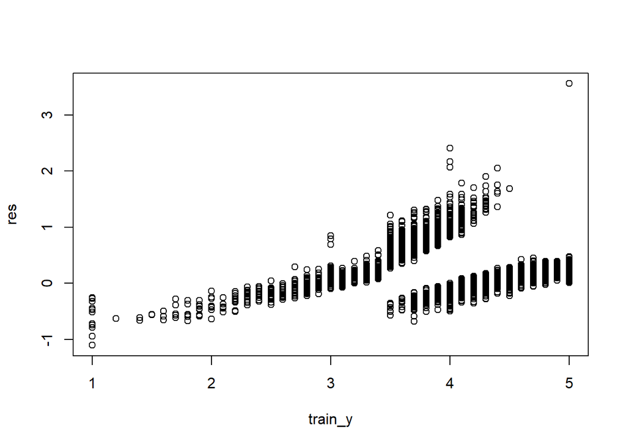

```r
res<-train_y-training_preds
plot(train_y,res)
```

```r
pred_pop<-c()
for(i in seq(length(training_preds))){
  if(training_preds[i]<3.5){
    pred_pop<-append(pred_pop,"Bad")
  }
  else{
    pred_pop<-append(pred_pop,"Popular")
  }
}
table(true_pop,pred_pop)
```

```
##          pred_pop
## true_pop   Bad Popular
##   Bad      515       0
##   Popular  817    5226
```

## Prediction on test set using default cutoff of 4

```r
test_data<-testing[c("Category", "Rating", "Reviews", "Size", "Installs", "Price", "Content.Rating","Current.Ver", "Android.Ver", "Days")]

dummy_Test<-model.matrix(Rating~.,test_data)
test_y<-test_data$Rating

testing_preds<-predict_review(dummy_Test)
rmse(test_y, testing_preds)
```

```
## [1] 0.6750767
```

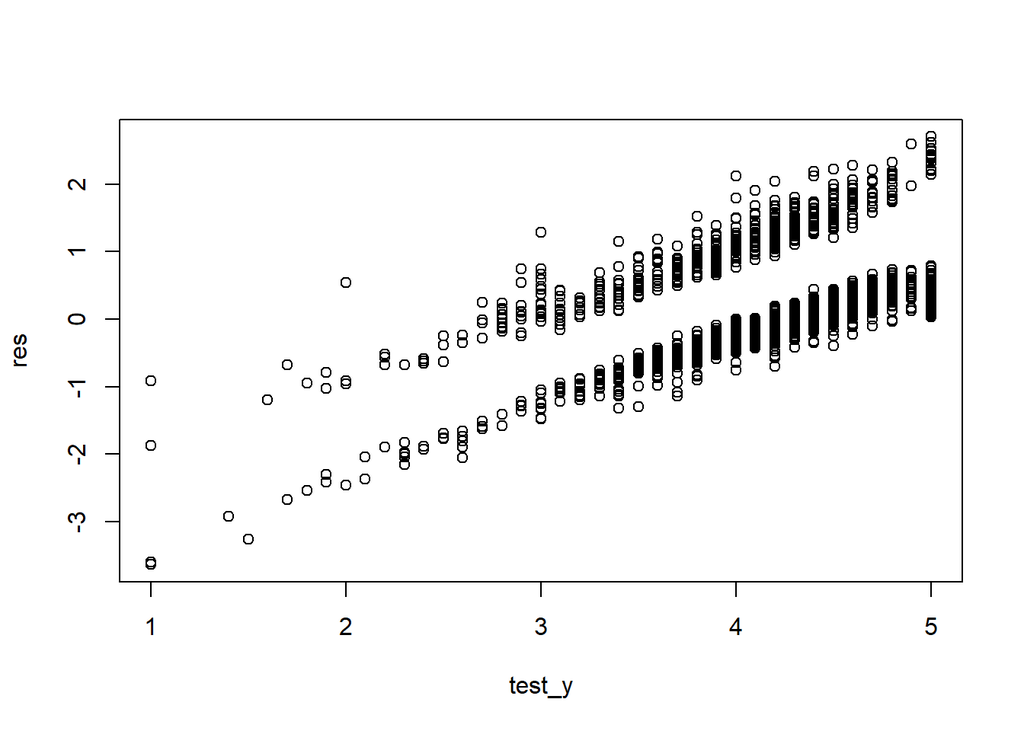

```r
res<-test_y-testing_preds
plot(test_y,res)
```

```r
true_test_pop<-c()
for(i in seq(length(test_y))){
  if(test_y[i] < 3.5){
    true_test_pop<-append(true_test_pop,"Bad")
  }
  else{
    true_test_pop<-append(true_test_pop,"Popular")
  }
}

test_pred_pop<-c()
for(i in seq(length(testing_preds))){
  if(testing_preds[i]<3.5){
    test_pred_pop<-append(test_pred_pop,"Bad")
  }
  else{
    test_pred_pop<-append(test_pred_pop,"Popular")
  }
}
table(true_test_pop,test_pred_pop)
```

```
##              test_pred_pop
## true_test_pop  Bad Popular
##       Bad      110     109
##       Popular  440    2150
```

```r
test_data<-testing[c("Category", "Rating", "Reviews", "Size", "Installs", "Price", "Content.Rating","Current.Ver", "Android.Ver", "Days")]

dummy_Test<-model.matrix(Rating~.,test_data)
test_y<-test_data$Rating

testing_preds<-predict_review(dummy_Test, 4.1)
rmse(test_y, testing_preds)
```

```
## [1] 0.7802803
```

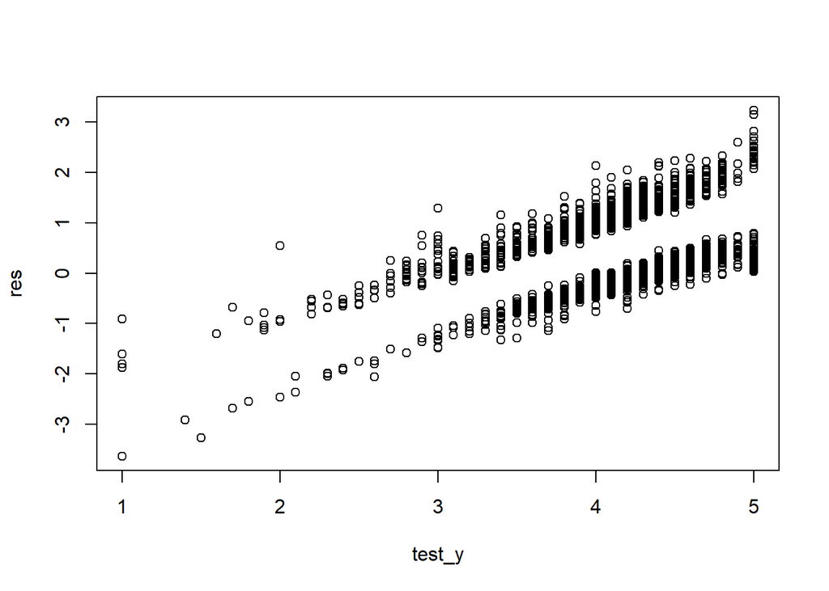

```r
res<-test_y-testing_preds
plot(test_y,res)
```

```r
true_test_pop<-c()
for(i in seq(length(test_y))){
  if(test_y[i] < 3.5){
    true_test_pop<-append(true_test_pop,"Bad")
  }
  else{
    true_test_pop<-append(true_test_pop,"Popular")
  }
}

test_pred_pop<-c()
for(i in seq(length(testing_preds))){
  if(testing_preds[i]<3.5){
    test_pred_pop<-append(test_pred_pop,"Bad")
  }
  else{
    test_pred_pop<-append(test_pred_pop,"Popular")
  }
}
table(true_test_pop,test_pred_pop)
```

```
##              test_pred_pop
## true_test_pop  Bad Popular
##       Bad      157      62
##       Popular  759    1831
```